# BIOST 2079 Final Project

Nick, Yufeng, Alexander, Jamal

2022-12-12

## Introduction

### Background

The World Health Organization (WHO) estimates that 12 million deaths occur across the world every year due to heart diseases. In fact, half of deaths in the United States and other developed countries are due to cardiovascular diseases. Early identification of risk for cardiovascular disease can allow high risk individuals to make lifestyle changes in order to reduce the chance of developing complications. The purpose of this project was to use the well-known framingham.csv dataset to identify relevant risk factors for heart disease, as well as predict overall risk using a variety of classification methods.

### Data Source

Our dataset is from an ongoing cardiovascular study on residents of the town of Framingham, Massachusetts. The dataset includes a range of predictors (demographic, behavioral, medical history, etc.), as well as a binary outcome variable for the 10-year risk of coronary heart disease (CHD). It includes over 4,000 records and 15 attributes. The variables in the data are summarized below:

Demographic: - Sex: male or female (nominal) - Age: Age of the patient (continuous)

Behavioral: - Current Smoker: whether or not the patient is a current smoker (nominal) - Cigs Per Day: the number of cigarettes that the person smoked on average in one day (continuous)

Medical History - BP Meds: whether or not the patient was on blood pressure medication (nominal) - Prevalent Stroke: whether or not the patient had previously had a stroke (nominal) - Prevalent Hyp: whether or not the patient was hypertensive (nominal) - Diabetes: whether or not the patient had diabetes (nominal)

Clinical Variables - Tot Chol: total cholesterol level (continuous) - Sys BP: systolic blood pressure (continuous) - Dia BP: diastolic blood pressure (continuous) - BMI: Body Mass Index (continuous) - Heart Rate: heart rate (continuous) - Glucose: glucose level (continuous)

Outcome Variable - 10 year risk of coronary heart disease CHD (binary: 1 = yes, 0 = no)

Reference - https://www.kaggle.com/datasets/dileep070/heart-disease-prediction-using-logistic-regression

## Package and Data Loading

```r
library(dplyr)
```

```r
library(ggplot2)
library(pROC)
library(MASS) # lda, qda
library(caret)
library(corrplot)
library(randomForest)
data <- read.csv("framingham.csv")
summary(data)
```

```
##       male             age          education     currentSmoker
##  Min.   :0.0000   Min.   :32.00   Min.   :1.000   Min.   :0.0000
##  1st Qu.:0.0000   1st Qu.:42.00   1st Qu.:1.000   1st Qu.:0.0000
##  Median :0.0000   Median :49.00   Median :2.000   Median :0.0000
##  Mean   :0.4292   Mean   :49.58   Mean   :1.979   Mean   :0.4941
##  3rd Qu.:1.0000   3rd Qu.:56.00   3rd Qu.:3.000   3rd Qu.:1.0000
##  Max.   :1.0000   Max.   :70.00   Max.   :4.000   Max.   :1.0000
##                                   NA's   :105
##    cigsPerDay         BPMeds        prevalentStroke     prevalentHyp
##  Min.   : 0.000   Min.   :0.00000   Min.   :0.000000   Min.   :0.0000
##  1st Qu.: 0.000   1st Qu.:0.00000   1st Qu.:0.000000   1st Qu.:0.0000
##  Median : 0.000   Median :0.00000   Median :0.000000   Median :0.0000
##  Mean   : 9.003   Mean   :0.02963   Mean   :0.005899   Mean   :0.3105
##  3rd Qu.:20.000   3rd Qu.:0.00000   3rd Qu.:0.000000   3rd Qu.:1.0000
##  Max.   :70.000   Max.   :1.00000   Max.   :1.000000   Max.   :1.0000
##  NA's   :29       NA's   :53
##     diabetes          totChol          sysBP           diaBP
##  Min.   :0.00000   Min.   :107.0   Min.   : 83.5   Min.   : 48.00
##  1st Qu.:0.00000   1st Qu.:206.0   1st Qu.:117.0   1st Qu.: 75.00
##  Median :0.00000   Median :234.0   Median :128.0   Median : 82.00
##  Mean   :0.02572   Mean   :236.7   Mean   :132.4   Mean   : 82.89
##  3rd Qu.:0.00000   3rd Qu.:263.0   3rd Qu.:144.0   3rd Qu.: 89.88
##  Max.   :1.00000   Max.   :696.0   Max.   :295.0   Max.   :142.50
##                    NA's   :50
##       BMI          heartRate         glucose         TenYearCHD
##  Min.   :15.54   Min.   : 44.00   Min.   : 40.00   Min.   :0.000
##  1st Qu.:23.07   1st Qu.: 68.00   1st Qu.: 71.00   1st Qu.:0.000
##  Median :25.40   Median : 75.00   Median : 78.00   Median :0.000
##  Mean   :25.80   Mean   : 75.88   Mean   : 81.97   Mean   :0.152
##  3rd Qu.:28.04   3rd Qu.: 83.00   3rd Qu.: 87.00   3rd Qu.:0.000
##  Max.   :56.80   Max.   :143.00   Max.   :394.00   Max.   :1.000
##  NA's   :19      NA's   :1        NA's   :388
```

```r
head(data)
```

```
##   male age education currentSmoker cigsPerDay BPMeds prevalentStroke
## 1    1  39         4             0          0      0               0
## 2    0  46         2             0          0      0               0
## 3    1  48         1             1         20      0               0
## 4    0  61         3             1         30      0               0
## 5    0  46         3             1         23      0               0
## 6    0  43         2             0          0      0               0
##   prevalentHyp diabetes totChol sysBP diaBP   BMI heartRate glucose TenYearCHD
## 1            0        0     195 106.0    70 26.97        80      77          0
## 2            0        0     250 121.0    81 28.73        95      76          0
## 3            0        0     245 127.5    80 25.34        75      70          0
## 4            1        0     225 150.0    95 28.58        65     103          1
## 5            0        0     285 130.0    84 23.10        85      85          0
## 6            1        0     228 180.0   110 30.30        77      99          0
```

## Data Preprocessing

First, let’s take a look at the missing counts for each variable.

```r
Na <- (sapply(data, function(x) (sum(is.na(x))/nrow(data))*100)) # calculates the number of missing data for each variable divided by the total number of rows or cases.

Percent_Missing <- Na[order(-Na)] # orders the NA percentages in descending order
head(data.frame(Percent_Missing),10) #displays the first 10 variables.
```

```
##               Percent_Missing
## glucose            9.15526192
## education          2.47758377
## BPMeds             1.25058990
## totChol            1.17980179
## cigsPerDay         0.68428504
## BMI                0.44832468
## heartRate          0.02359604
## male               0.00000000
## age                0.00000000
## currentSmoker      0.00000000
```

Since we don’t have that many missing values, we can simply remove observations with missing values for any variable.

```r
data <- na.omit(data)
```

From our inspection of the data, we can also see that many of our variables are of the incorrect data type. Let’s fix this…

```r
factor_variables <- c('male', 'education', 'currentSmoker', 'BPMeds', 'prevalentStroke', 'prevalentHyp', 'diabetes', 'TenYearCHD')

for(column in factor_variables){
  data[, column] <- as.factor(data[, column])
}

head(data)
```

```
##   male age education currentSmoker cigsPerDay BPMeds prevalentStroke
## 1    1  39         4             0          0      0               0
## 2    0  46         2             0          0      0               0
## 3    1  48         1             1         20      0               0
## 4    0  61         3             1         30      0               0
## 5    0  46         3             1         23      0               0
## 6    0  43         2             0          0      0               0
##   prevalentHyp diabetes totChol sysBP diaBP   BMI heartRate glucose TenYearCHD
## 1            0        0     195 106.0    70 26.97        80      77          0
## 2            0        0     250 121.0    81 28.73        95      76          0
## 3            0        0     245 127.5    80 25.34        75      70          0
## 4            1        0     225 150.0    95 28.58        65     103          1
## 5            0        0     285 130.0    84 23.10        85      85          0
## 6            1        0     228 180.0   110 30.30        77      99          0
```

## Principal Component Analysis (PCA)

First, let’s perform PCA on the continuous predictors. We will keep two separate datasets - one with the PCA data, and one with the original data.

```r
## subset data to pca
pca_var <- c('age', 'cigsPerDay', 'totChol', 'sysBP', 'diaBP', 'BMI', 'heartRate', 'glucose')
pca_var_index <- which(colnames(data) %in% pca_var)
pca_data_untransformed <- data[, pca_var_index]
other_data <- data[, -pca_var_index]

## perform pca
pca_results <- prcomp(pca_data_untransformed, center = TRUE, scale = TRUE)
pca_data_transformed <- pca_results$x[, c(1, 2)]

pca_data <- cbind(pca_data_transformed, other_data)
```

## Exploratory Data Analysis

Now, we will examine some of the relationships in the data through visualization. First, let’s make a plot of the first two principal components from PCA.

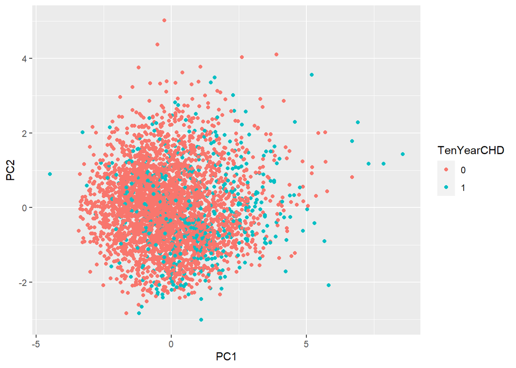

```r
pca_data %>%
  ggplot() +
  geom_point(aes(x = PC1, y = PC2, color = TenYearCHD))
```

The first two principal components don’t appear to reveal any information about the outcome (i.e., there aren’t distinct clusters of either outcome).

## Model Fitting

In this section, we will fit multiple models and compare them via test set accuracy and AUC.

First, let’s divide the data into training and testing sets. We will use an 60:40 split (train:test).

```r
## set seed for reproducibility
set.seed(15213)

## generate samples
sub_sample <- sample(nrow(data), size = nrow(data)*0.60)

## divide data
train <- data[sub_sample, ]
test <- data[-sub_sample, ]
```

Let’s take a closer look at the distribution of the outcome across the splits.

```r
summary(train$TenYearCHD)
```

```
##    0    1
## 1844  349
```

```r
summary(test$TenYearCHD)
```

```
##    0    1
## 1255  208
```

### Logistic Regression

Now, let’s fit a series of logistic regression models. We will consider models for all additive inputs, different combinations of interactions, and subset versions containing only the important features.

All additive inputs:

```r
mod1 <- glm(formula = TenYearCHD ~ ., family = 'binomial', data = train)
```

Additive inputs subset to significant predictors:

```r
mod2 <- glm(formula = TenYearCHD ~ male + age + cigsPerDay + totChol + sysBP + glucose, family = 'binomial', data = train)
```

All pair-wise interactions:

```r
mod3 <- glm(formula = TenYearCHD ~ . * ., family = 'binomial', data = train)
```

All pair-wise interactions on significant features:

```r
mod4 <- glm(formula = TenYearCHD ~ (male + age + cigsPerDay + totChol + sysBP + glucose) *
              (male + age + cigsPerDay + totChol + sysBP + glucose), family = 'binomial', data = train)
```

Manually selected interactions:

```r
mod5 <- glm(formula = TenYearCHD ~ male * (education + prevalentHyp) + education * (currentSmoker + totChol) + cigsPerDay + (sysBP + diaBP) + heartRate * (diabetes + glucose + sysBP) + age, family = 'binomial', data = train)
```

### Machine Learning Techniques: K-Nearest Neighbors (KNN) and Random Forest (RF)

In this section, we will fit a few models using various machine learning techniques (KNN and RF).

First, we need to prepare our data for model fitting using caret.

```r
levels(train$TenYearCHD) <- c("neg", "pos")
levels(test$TenYearCHD) <- c("neg", "pos")
```

```r
y.train <- train$TenYearCHD
y.test <- test$TenYearCHD
x.train <- train[,c(1:15)]
x.test <- test[,c(1:15)]
```

Next, define our modeling approach

```r
ctrl <- trainControl(method = "repeatedcv",
                     number = 10,
                     repeats = 1,
                     summaryFunction = twoClassSummary,
                     classProbs = TRUE)
```

And finally, fit each model.

```r
## set seed for reproducibility
set.seed(1)

## manually define tuning parameter grid
knn.grid <- data.frame(k = seq(1,200,by=5))

## fit KNN model
mod6 <- train(x = x.train,
              y = y.train,
              method = "knn",
              preProcess = c("center","scale"), # based on the distance, so center and scale is recommended
              tuneGrid = knn.grid, # tuning parameter: more is better
              metric = "ROC",
              trControl = ctrl)
```

```r
## set seed for reproducibility
set.seed(1)

## manually define tuning parameter grid
rf.grid <- expand.grid(mtry = 1:6,
                       splitrule = "gini",
                       min.node.size = 1:6)

## fit RF model
mod7 <- train(x = x.train,
              y = y.train,
              method = "ranger",
              tuneGrid = rf.grid,
              metric = "ROC",
              trControl = ctrl)
```

## Model Evaluation

In order to compare all of our models, we must each model’s predictions on the test set, and then calculate the relevant evaluation metrics (here, we are most interested in the AUC and confusion matrices, but we have also included various evaluation indices and calibration curves).

### Predictions

First, let’s get our predictions from each model using the test set.

```r
pred1 <- predict(mod1, newdata = test, type = 'response')
pred2 <- predict(mod2, newdata = test, type = 'response')
pred3 <- predict(mod3, newdata = test, type = 'response')
pred4 <- predict(mod4, newdata = test, type = 'response')
pred5 <- predict(mod5, newdata = test, type = 'response')
pred6 <- predict(mod6, newdata = test, type = "prob")[,2]
pred7 <- predict(mod7, newdata = test, type = "prob")[,2]
```

### Test Set AUC

Next, calculate and plot AUC for each model.

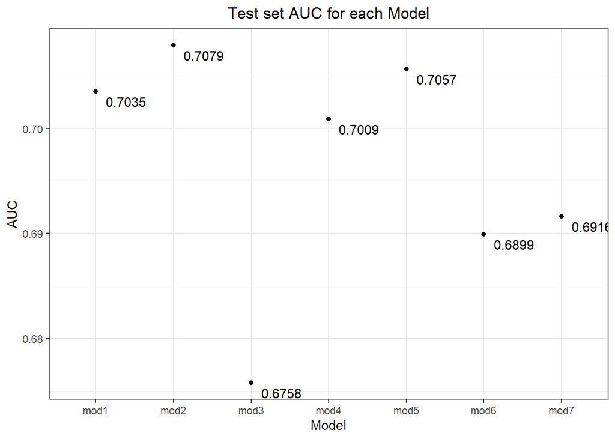

```r
auc1 <- auc(test$TenYearCHD, pred1)
auc2 <- auc(test$TenYearCHD, pred2)
auc3 <- auc(test$TenYearCHD, pred3)
auc4 <- auc(test$TenYearCHD, pred4)
auc5 <- auc(test$TenYearCHD, pred5)
auc6 <- auc(y.test, pred6)
auc7 <- auc(y.test, pred7)

auc_df <- data.frame(model = c("mod1", "mod2", "mod3", "mod4", "mod5", "mod6", "mod7"),
                     auc = c(auc1, auc2, auc3, auc4, auc5, auc6, auc7))

auc_df %>%
  ggplot(aes(x = as.factor(model), y = auc)) +
  geom_point() +
  geom_text(aes(label = as.character(round(auc, 4))), hjust = -0.25, vjust = 1.5) +
  xlab("Model") +
  ylab("AUC") +
  ggtitle("Test set AUC for each Model") +
  theme_bw() +
  theme(plot.title = element_text(hjust = 0.5))
```

### Test Set Confusion Matrices (and other evaluation indices)

First, we will define a function which takes the confusion matrix as input and outputs a series of evaluation indices.

```r
#error metrics -- Confusion Matrix Function
err_metric=function(CM)
{
  TN =CM[1,1]
  TP =CM[2,2]
  FP =CM[1,2]
  FN =CM[2,1]
  precision =(TP)/(TP+FP)
  recall_score =(FP)/(FP+TN)
  f1_score=2*((precision*recall_score)/(precision+recall_score))
  accuracy_model  =(TP+TN)/(TP+TN+FP+FN)
  False_positive_rate =(FP)/(FP+TN) # Recall Score
  False_negative_rate =(FN)/(FN+TP)
  Sensitivity = (TP)/(TP+FN)
  Specificity = (TN)/(TN+FP)
  MCC = (TP*TN-FP*FN) / sqrt(((TP+FN)*(TP+FN)*(TN+FP)*(TN+FN)))
  print(paste("Sensitivity:    ",round(Sensitivity,2)))
  print(paste("Specificity:    ",round(Specificity,2)))
  print(paste("Precision:      ",round(precision,2))) # Calculation of the true positives out of all positive rated cases
  print(paste("Accuracy:       ",round(accuracy_model,2)))
  print(paste("Recall:         ",round(recall_score,2)))
  print(paste("False Positive: ",round(False_positive_rate,2))) # Same as recall
  print(paste("False Negative: ",round(False_negative_rate,2)))
  print(paste("F1 score:       ",round(f1_score,2))) # Closer to 1, the better the model.
  print(paste("MCC score:      ",round(MCC,2))) # Between -1 and 1, the better the classifier; 0 = very random; 1 = Perfect classifier.

}
```

Confusion Matrix Mod1 - Mod5

```r
test$PredDir <- ifelse(pred1 > 0.5, 1, 0)
CM.1 = table(test$PredDir, test$TenYearCHD)
print(CM.1)
```

```
##
##      neg  pos
##   0 1234  190
##   1   21   18
```

```r
err_metric(CM.1)
```

```
## [1] "Sensitivity:     0.46"
## [1] "Specificity:     0.87"
## [1] "Precision:       0.09"
## [1] "Accuracy:        0.86"
## [1] "Recall:          0.13"
## [1] "False Positive:  0.13"
## [1] "False Negative:  0.54"
## [1] "F1 score:        0.1"
## [1] "MCC score:       NA"
```

```r
test$PredDir <- ifelse(pred2 > 0.5, 1, 0)
CM.2 = table(test$PredDir, test$TenYearCHD)
print(CM.2)
```

```
##
##      neg  pos
##   0 1239  190
##   1   16   18
```

```r
err_metric(CM.2)
```

```
## [1] "Sensitivity:     0.53"
## [1] "Specificity:     0.87"
## [1] "Precision:       0.09"
## [1] "Accuracy:        0.86"
## [1] "Recall:          0.13"
## [1] "False Positive:  0.13"
## [1] "False Negative:  0.47"
## [1] "F1 score:        0.1"
## [1] "MCC score:       0.42"
```

```r
test$PredDir <- ifelse(pred3 > 0.5, 1, 0)
CM.3 = table(test$PredDir, test$TenYearCHD)
print(CM.3)
```

```
##
##      neg  pos
##   0 1201  179
##   1   54   29
```

```r
err_metric(CM.3)
```

```
## [1] "Sensitivity:     0.35"
## [1] "Specificity:     0.87"
## [1] "Precision:       0.14"
## [1] "Accuracy:        0.84"
## [1] "Recall:          0.13"
## [1] "False Positive:  0.13"
## [1] "False Negative:  0.65"
## [1] "F1 score:        0.13"
## [1] "MCC score:       NA"
```

```r
test$PredDir <- ifelse(pred4 > 0.5, 1, 0)
CM.4 = table(test$PredDir, test$TenYearCHD)
print(CM.4)
```

```
##
##      neg  pos
##   0 1230  191
##   1   25   17
```

```r
err_metric(CM.4)
```

```
## [1] "Sensitivity:     0.4"
## [1] "Specificity:     0.87"
## [1] "Precision:       0.08"
## [1] "Accuracy:        0.85"
## [1] "Recall:          0.13"
## [1] "False Positive:  0.13"
## [1] "False Negative:  0.6"
## [1] "F1 score:        0.1"
## [1] "MCC score:       NA"
```

```r
test$PredDir <- ifelse(pred5 > 0.5, 1, 0)
CM.5 = table(test$PredDir, test$TenYearCHD)
print(CM.5)
```

```
##
##      neg  pos
##   0 1230  189
##   1   25   19
```

```r
err_metric(CM.5)
```

```
## [1] "Sensitivity:     0.43"
## [1] "Specificity:     0.87"
## [1] "Precision:       0.09"
## [1] "Accuracy:        0.85"
## [1] "Recall:          0.13"
## [1] "False Positive:  0.13"
## [1] "False Negative:  0.57"
## [1] "F1 score:        0.11"
## [1] "MCC score:       NA"
```

```r
yhat.KNN <- predict(mod6, newdata=test)
CM.6 = table(yhat.KNN, y.test)
print(CM.6)
```

```
##         y.test
## yhat.KNN  neg  pos
##      neg 1255  208
##      pos    0    0
```

```r
err_metric(CM.6)
```

```
## [1] "Sensitivity:     NaN"
## [1] "Specificity:     0.86"
## [1] "Precision:       0"
## [1] "Accuracy:        0.86"
## [1] "Recall:          0.14"
## [1] "False Positive:  0.14"
## [1] "False Negative:  NaN"
## [1] "F1 score:        0"
## [1] "MCC score:       NaN"
```

```r
yhat.RF <- predict(mod6, newdata=test)
CM.7 = table(yhat.RF, y.test)
print(CM.7)
```

```
##        y.test
## yhat.RF  neg  pos
##     neg 1255  208
##     pos    0    0
```

```r
err_metric(CM.7)
```

```
## [1] "Sensitivity:     NaN"
## [1] "Specificity:     0.86"
## [1] "Precision:       0"
## [1] "Accuracy:        0.86"
## [1] "Recall:          0.14"
## [1] "False Positive:  0.14"
## [1] "False Negative:  NaN"
## [1] "F1 score:        0"
## [1] "MCC score:       NaN"
```

ROC Curves

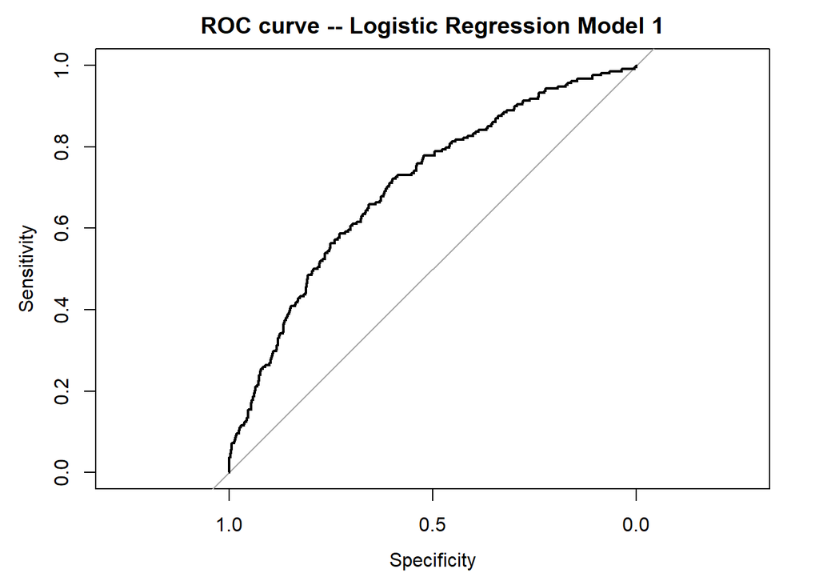

```r
#ROC curve Scores
roc_score.1 = roc(test[,16], pred1) #AUC score
roc_score.2 = roc(test[,16], pred2) #AUC score
roc_score.3 = roc(test[,16], pred3) #AUC score
roc_score.4 = roc(test[,16], pred4) #AUC score
roc_score.5 = roc(test[,16], pred5) #AUC score
roc_score.6 = roc(test[,16], pred6) #AUC score
roc_score.6 = roc(y.test, pred6) #AUC score
roc_score.7 = roc(y.test, pred7) #AUC score
# ROC Plots
plot(roc_score.1, main ="ROC curve -- Logistic Regression Model 1")
```

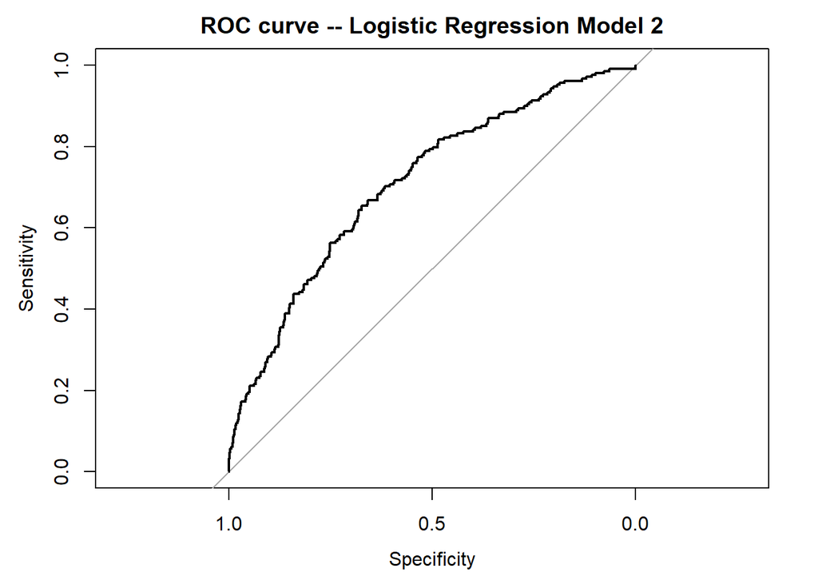

```r
plot(roc_score.2, main ="ROC curve -- Logistic Regression Model 2")
```

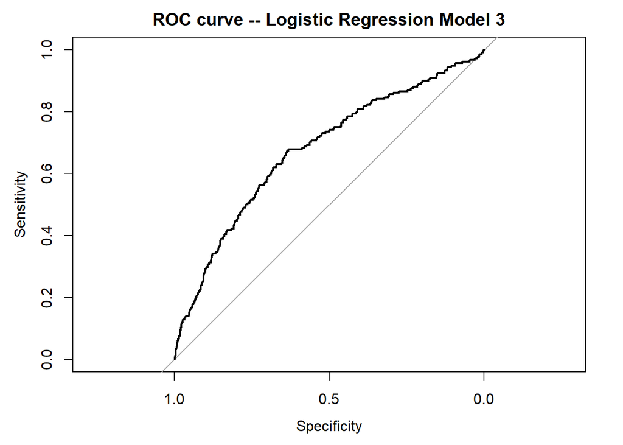

```r
plot(roc_score.3, main ="ROC curve -- Logistic Regression Model 3")
```

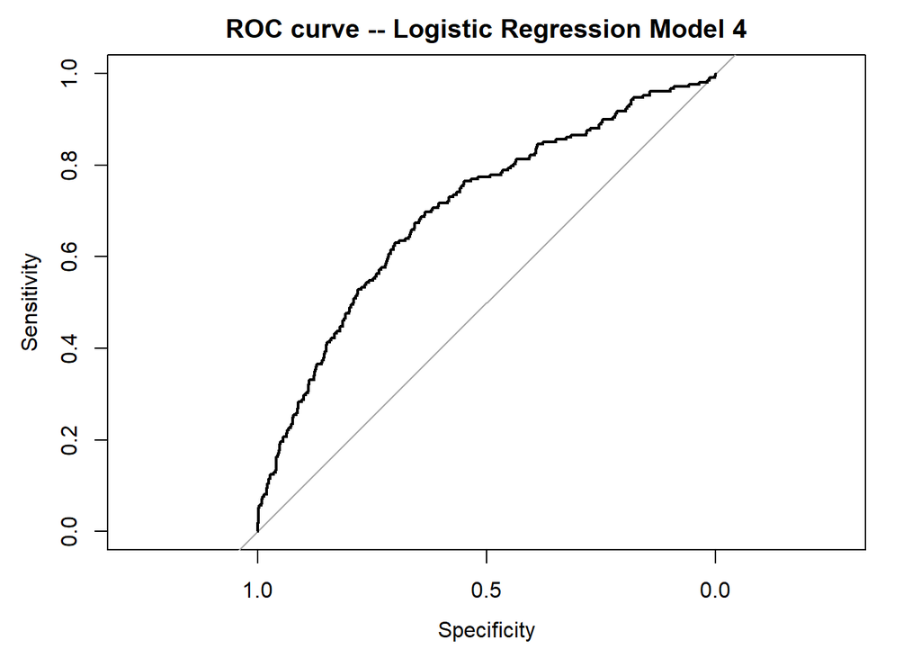

```r
plot(roc_score.4, main ="ROC curve -- Logistic Regression Model 4")
```

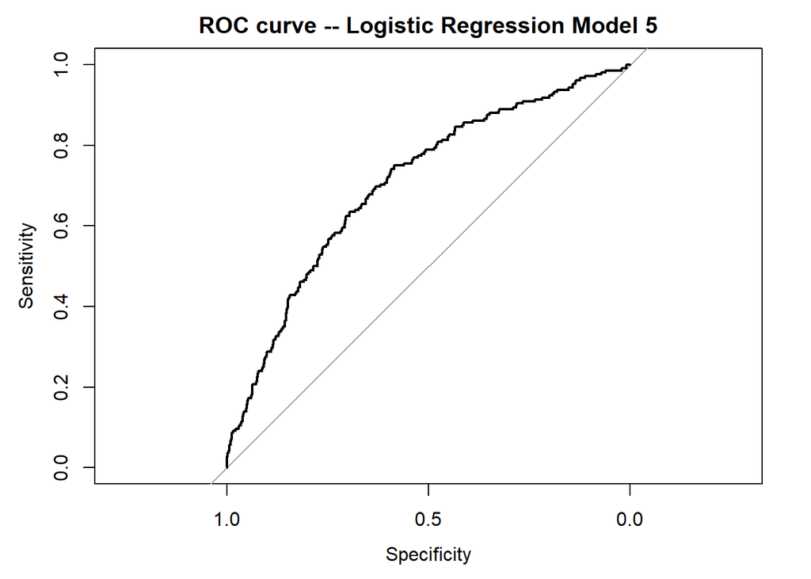

```r
plot(roc_score.5, main ="ROC curve -- Logistic Regression Model 5")
```

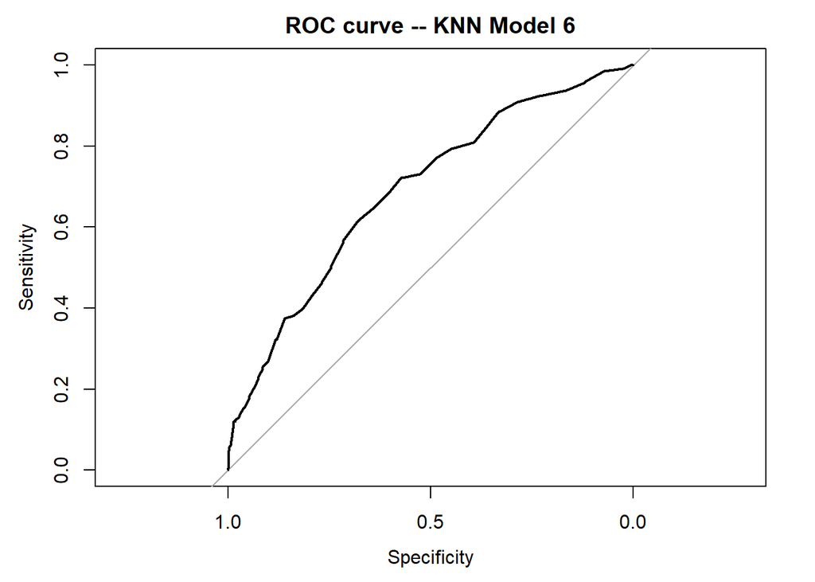

```r
plot(roc_score.6, main ="ROC curve -- KNN Model 6")
```